# BIOST 561: vscode, python, and chatgpt

Lecture 10

# Announcements

- I’ll start grading HW4 on Saturday, so no worries if you need until Friday night to submit it (if you haven’t done so already)
- Please make sure you push the HW4 (both the `.Rmd` and `.html` file) onto GitHub, as well as all the `.R` and `.slurm` scripts you used.
  - The `.html` file for HW4 should show the plot your simulation setting made
- The goal of the “code review” in HW4 was mainly to give you experience reading other people’s code – hopefully you are as critical of your own code as you are of other people’s code
- No lecture next week (this is last one!)
  - I’ll be having OH during class time next week (Thursday, 6/6, 9:30-11:20am, in my office), as well as the usual OH for the course (Friday, 6/7, noon-1pm). This is mainly if you have questions about the final project or if you wanted to drop by to double check all your HW submissions are marked as complete

# Plan for today

- Finish going over PkgDown and Github.io
- Go over the final project
- Demo **very quickly** how to use Python
  - VSCode as the GUI: Analogous to RStudio for R
  - Jupyter notebooks for the interactive way to use Python: Analogous to R Markdowns
  - pip as the package manager: Analogous to `install.packages()` in R (but you install packages not in python, but in the terminal)
  - ChatGPT as the way to learn Python: Analogous to taking a coding course to learn R
- Recap the main themes of course

# What to mentally prepare yourself for when you’re using Python even though you’re used to R

- Python changes **very fast** compared to R. The version of Python changes all the time, and the packages themselves are changing all the time
  - In R, you probably never worried about which literal version of R you’re using. In Python, you have to pay close attention to which version of Python you’re using
  - I have many instances where code that installed smoothly a couple months ago will **not install** smoothly now
- Package management is very different also
  - You will frequently have instances where you cannot install two packages at the same time since they conflict with one another

**Be patient with yourself**: You will feel like you’re going crazy since you will have trouble doing “very simple things.” They’re only “simple” since you’re familiar with how to do them in R!

# My recommended order-of-operations to set up Python

**I will not have time to demo this in class**. Follow this at your own pace on your own time, but this is meant to give you one plausible strategy to set up Python on your laptop.

- Install Visual Studio (commonly called “VS Code”): https://visualstudio.microsoft.com/free-developer-offers/ – You want the “blue one”, not the “purple one”
- Install Miniconda (more on this later)
- On your Terminal (for Macs, or Powershell for Windows): Create a virtual environment with the appropriate version of python you want
- On your Terminal: Activate your virtual environment
- On your Terminal: Install all your intended packages, ideally via `pip` (but sometimes you will need to install it via `conda`)
- In VSCode: Open up a new Jupyter Notebook script, and import all the packages you need
- In VSCode: When you run a script, VSCode will ask you which virtual environment you want to use. Use the virtual environment you just made. (It might also install the `ipykernel` package)
- Then you’ll be done!

If you were setting this up on Bayes, you won’t be interacting with Python via VSCode. (Similar to how you cannot use R Studio on Bayes, you cannot use VSCode on Bayes.) – This is technically not true if you set up tunneling or remote-SSH, but I won’t talk about that.

# What is Miniconda?

See https://docs.anaconda.com/

Just a note about naming:

- Python got its name from on the interests of the creator based the British sketch show: Monty Python (the same series of “Monty Python and the Holy Grail”)
- Anaconda (which is type of snake) is a play on the animal “Python” (another type of snake)

Anaconda is a **distribution** of Python. (Think of it this way: Python is the programming language, Anaconda contains Python and a lot more)

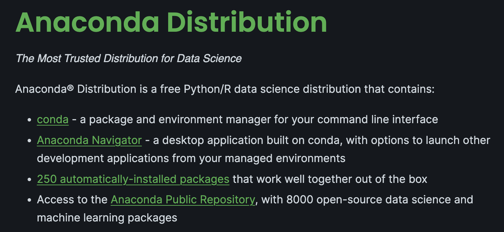

Miniconda is a **lightweight** version of Anaconda. (Think of it this way: Anaconda is a fully furished house that you move into, and Miniconda is a house you move into without any furniture)

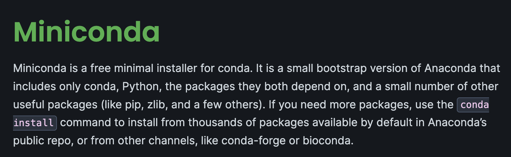

To see the distinction, see the following screenshot:

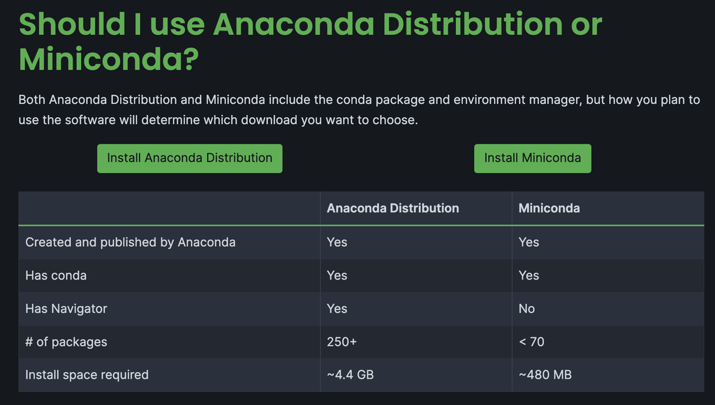

In general, I would recommend using Miniconda since it’s easier to work with – you can always manually install all the additional things you need that Miniconda is missing.

# Short demo

I’ll now show a quick demo of how to use Python, how to create virtual environments via `conda`, how to install packages, and how to open up a Jupyter notebook and load those pacakges.

# Now, where does ChatGPT come into the picture?

**Note**: All the following slides about ChatGPT are my **personal opinion** (not the opinion of the department). I’m positive different faculty members have different opinions (which is a good thing – it’s a good thing there’s a diversity of opinions on important matters). These are simply my own opinions.

- When you’re using GPT-4o, your GPT prompt can actually **analyze data in Python** (using Python 3.8 I think)

[figure not shown]

- Using GPT-4o to create a simple deep learning example using PyTorch
  - See https://github.com/linnykos/561_s2024_public/blob/main/lecture10_files/chatGPT_log1.pdf

# Using ChatGPT to learn

- Using GPT-4o to interactively learn more about coding in Python
  - See https://github.com/linnykos/561_s2024_public/blob/main/lecture10_files/chatGPT_log3.pdf for a variational auto-encoder example
- Think of ChatGPT as a motivated, 24-hour on-call tutor who is a senior undergraduate who specializes in any field you want. Not the tip-top expert, but definitely still very useful if you’re not very familiar with a field
  - This is useful for learning some basic coding or basic biology (when you collaborate with scientists), etc.
  - Be mindful – there might be inaccuracies in what ChatGPT tells you, so **do not quote/cite** ChatGPT. Instead, use it as a rough guide on a new topic to get a sense. Be sure to find actual evidence to back up the things you learn via ChatGPT.
  - For instance, when it comes to cell biology, the concepts in cell biology 10 years ago are now slightly not-true in 2024. Science is constantly evolving, so there’s no harm in using ChatGPT to get a rough sense of the field, but its scientific information is likely not entirely factually accurate in 2024-standards.
- I use ChatGPT for this **a lot**.

# Using ChatGPT to analyze data

- Using GPT-4o to help you analzye data
  - See https://github.com/linnykos/561_s2024_public/blob/main/lecture10_files/chatGPT_log2.pdf for analyzing the penguin data that you worked on in HW2
- It’s not perfect (and often it can’t execute the code it writes since it can only analyze data using certain packages), but for very simple things, it’s reasonable
  - There’s a limit on how much time the code can run for and how much data you can feed it
  - I wouldn’t rely on this, but this will probably get more sophisticated within the next year or two. Who am I to judge?

# Using ChatGPT to do simple things for you

- (Not specific to Python)
- You can also use ChatGPT to do more mundane things for you (formatting text)
- As you probably tried in some of the homeworks, you can use ChatGPT to also help write some code for you (although you need to be pretty specific about what you’re asking for) or suggest some unit tests
- I use ChatGPT for this somewhat often, especially when I forget how to code something in Python or how to use all the nuances of ggplot.

# What wouldn’t I recommend ChatGPT for?

There are some things I personally wouldn’t recommend using ChatGPT for. (Not to say there’s no value in using it like this, but simply I would proceed with caution in these instances.)

- Writing. (I think ChatGPT is pretty good at writing really generic things – things you personally don’t care too much about, for example: mundane emails to your landlord.)
  - For more important writing (i.e., writing where you want to build a connection with the audience you are writing for), I would avoid using ChatGPT for the writing.
  - In general, it’s not that hard to tell a writing was done by ChatGPT
  - ChatGPT is probably better suited for revising non-academic writing
- Revising academic writing
  - ChatGPT doesn’t know which part of the paper is “redundant”, so it might cut out parts of the text that are important
  - In some sense, ChatGPT is exactly doing the opposite of what you want. It keeps the parts that are well known by the literature (since it’s trained on all existing text), and it throws out all the parts that is novel (since not much text on the internet is about the novel thing you’re working on)
- Brainstorm the “bigger picture” of a codebase or a grander research project
  - ChatGPT is good at small, simple, concrete things
  - When it comes to a task that is too grand in scale (for example, your research project for your PhD or for your consulting work), ChatGPT might not meaningfully break down the bigger task into small modules
  - This is exactly where your training comes in – how to think big-picture about statistical analyses, how to convert public-health questions into math questions, how to structure a codebase to develop new methods and analyze data

# What I really would discourage you using ChatGPT for?

- Finding relevant papers
  - **PLEASE PROCEED WITH EXTREME CAUTION** when you’re asking ChatGPT to cite its sources
  - ChatGPT still currently “hallucinates” its citations (as of 2024)
  - See https://github.com/linnykos/561_s2024_public/blob/main/lecture10_files/chatGPT_log5.pdf for an example on post-selection inference for high-dimensional statistics. (This is a topic that many of our faculty such as Daniela, Ali, me, etc. have worked on).
  - Notice how convincing-sounding the references are, and if you look into it, none of the links or papers actually exist
- Deriving math
  - Currently, in the year 2024, ChatGPT is pretty clunky in deriving math things
  - The main frustration is similar to coding – the math (if you looked at it for less than 30 seconds) might look correct, but you’re not quite sure if it’s actually correct
  - The process of “double-checking” ChatGPT’s math is quite painful. (Again, think of ChatGPT as a motivated senior undergrad. You were all undergrads yourselves – it’s hard to really know when the “math is right” without carefully going through it)
  - Unlike coding, there’s no a simple way (yet) to verify if the “math works”. (With coding, you can just run the code to see if it works)
  - See https://github.com/linnykos/561_s2024_public/blob/main/lecture10_files/chatGPT_log4.pdf for an example on deriving the bandwidth for the histogram estimator
  - See https://faculty.washington.edu/yenchic/19A_stat535/Lec2_density.pdf (from a fellow faculty in UW Stats) for a proper derivation. ChatGPT’s derivation in this example isn’t on the same thing (it’s proving the MISE, and it’s deriving bandwidth instead of the number of bins, etc.)
  - And this is on a “well-studied, commonly taught” example. For “research-grade, unstudied problems”, I really wouldn’t trust ChatGPT’s math.
- Generating figures for a research paper
  - **Please do not use GPT for this**. There are so many reasons on why this is bad idea, I’m not even sure where to start
  - 1. For ethical reasons, this is based on stealing the work of countless of graphic designers.
  - 2. For scientific accuracy reasons, the labelings of these figures are almost hallucinated and often mislabeled, not actual words, or completely nonsensical
  - 3. For scientific integrity reasons, these figures are “made up” so they don’t reflect any actual results or true statistics/biology/public-health.
  - 4. For your own safety, it’s **much easier to watermark images** than it is text. Unlike text, you probably don’t have the skills to simply be “inspired by an image to make your own image from scratch.”
  - And many more reasons. Just don’t do this. I don’t see a future where using ChatGPT to make images becomes reasonable for any part of the research process.
  - Even when it comes to ChatGPT making a plot for you based on data analyses, **you** should still run the data analysis and generate the plot.
  - This is one of the few instances where I have a hard red-line on. I don’t see any reason why it’s ever a good idea for using ChatGPT to make figures for you.

# Last things about ChatGPT

- When using it for coding, **ALWAYS ALWAYS** be attentive to read the code before blindly copy-pasting it
  - There is a huge security concern going on in the field about ChatGPT being tricked into injecting malicious code into its output that you might unsuspectingly run. (I.e., you might be unknowningly running malware.)
- When writing research papers, double check the conference/journal on its rules regarding ChatGPT
  - Some venues have explicit policies regarding ChatGPT
  - Likely (if not already), papers will be analyzed to detect “plagarism via ChatGPT”

# So… what’s *really* the goal of the course?

(Literally the slide from Lecture 1)

There is a ocean’s worth of difference between: 1) knowing how to write code, and 2) having the vision and execution to bring an entire vision’s into a stable code-base that other people can easily use.

You wouldn’t call:

- Anyone who can play the notes of Rachmaninoff No. 2, a master pianist
- Anyone who can sing Taylor Swift’s “Anti-Hero”, a star performer
- Anyone who can memorize Chris Murphy’s lines in Oppenheimer, a Oscar-winning actor

# Give me the vision

(Literally the slide from Lecture 1)

- A huge portion of the course is specifically about building familiarity with R packages and GitHub
- Why?
  - GitHub allows for efficient deployment of code so others can use it
  - There are tons of great software engineering tools in RStudio that are relevant for only R packages

# Last few words

Thank you for the wonderful quarter!

A few final things:

- Learning the “not-coding” parts of “software engineering” is a neverending process
  - For your research direction, whenever you realize the code you’re using is on GitHub, take a look at how it’s coded. You’ll learn a lot from reading professional code that you’ve been using.
  - I would encourage you (the students) to self-organize code-review sessions (somewhat like what you did for HW4). Critiquing the code is an important part of your growth (and what you do a lot of a software-driven companies).
- I am teaching BIOST 545 in the Winter next academic year
  - “Biostatistical Methods for Big Omics Data”
  - The course syllabus online is very out-of-date, but I’ll be basically taking you through the wanky and fascinating world of single-cell biology. We’ll straddle biology, technology, and statistical aspects of multiple topics.